# Resumo_Linguagem_R

Sumário

Pedro_Lima

15/10/2020

# 1 RMarkdown

## 1.1 Links

Site do Knitr com todas as configurações https://yihui.org/knitr/options/

Publicar no Github https://www.curso-r.com/blog/2019-08-28-bookdown/

## 1.2 Chunk

**error** = TRUE continua a renderização mesmo com erro  
**results** = FALSE oculta a saída de texto, mostra um resultado mais limpo, tem mais opções de escolha que não apenas F  
**echo** = F executa exibe os resultados e oculta o código, ótimo para figuras e gráficos  
**eval** = F não executa o código, útil quando vai apenas mostrar um código de exemplo  
**Include** = FALSE # executa código porém oculta códito e resultados, ótimo para utilizar os resultados sem imprimir  
**message** = FALSE #oculta mensagens do resultado  
**warning** = FALSE #oculta avisos do resultado  
**fig.show** = ‘hide’ gera o gráfico mas oculta na impressão  
**fig.cap** = “…” #define a legenda da figura aos resultados gráficos produzidas pelo chunk  
**fig.align:** define o alinhamento da figura produzida pelo chunk  
**fig.height e fig.width**: define as dimensões da figura produzida pelo chunk

## 1.3 Cache

Se ao rodar o knitr verificar que o código não mudou, busca o resultado armazenado no cache

**cache** = TRUE #Quando tiver cálculos muito grandes e demorados

CUIDADO: por padrão este sistema é baseado apenas no código do chunk e não em suas dependências.

```r
rawdata <- readr::read_csv("tables/table_mtcars.csv")
```

```r
#não identifica alterações no chunk anterior ou no banco de dados
mean(rawdata$mpg)
## [1] 20.09062
```

```r
#identificação de alteração do chunk anterior, mas não do arquivo. csv
mean(rawdata$mpg)
## [1] 20.09062
```

```r
#Força identificar alterações do arquivo .csv
rawdata <- readr::read_csv("tables/table_mtcars.csv")
mean(rawdata$mpg)
## [1] 20.09062
```

## 1.4 Impressão de figuras

**Sugestões**:

**fig.width** = 6, fig.asp = 0.618  
**out.width** = “70%,” fig.align = “center”

Para vários gráficos em uma única linha,

**fig.align** = “default”  
**Out.width** = “50% # para dois gráficos  
**Out.width** =”33% # para três gráficos  
**Out.width** = “25% # para quatro gráficos  
**fig.show**=‘**hold**’ #força quebrar blocos grandes de código com sua explicação e imprime o gráfico após, para não mostrar o gráfico escolha opção ‘**hide**’  
**fig.cap** =”texto para legenda"

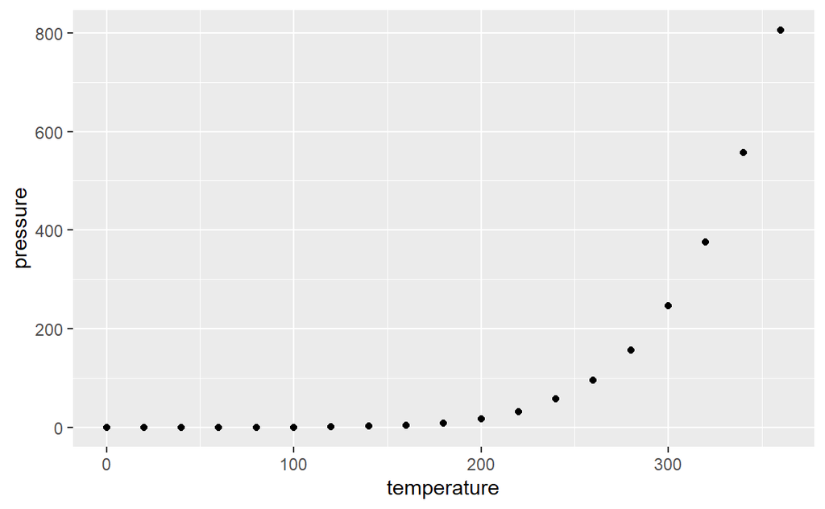

Texto para legenda

# 2 Github

## 2.1 Configurações

[figure not shown]

Configurar git

```r
git config –global user.name "pedro-pc"

git config –global user.email "pedroufv@yahoo.com.br"

git config –global core.editor "code –wait"
```

verificar se deu certo

```r
git config user.name

git config user.email

git config core.editor
```

Configurar chaves SSH

Para verificar se tem chave cadastrada pelo git bash

*ls -al ~/.ssh*

se tiver chave cadastrada

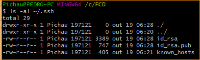

Se não tiver

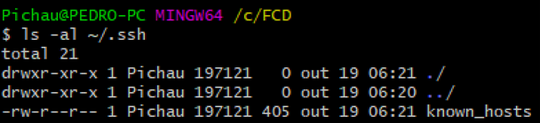

## 2.2 Configurações

### 2.2.1

```
git config –global user.name "pedro-pc"

git config –global user.email "pedroufv@yahoo.com.br"

git config –global core.editor "code –wait"
```

### 2.2.2 Verifica

```r
git config user.name

git config user.email

git config core.editor
```

Meu nome é pedro